# Homework 3: KNN

```r
library(scales)
train<-read.csv("Churn train.csv")
```

# Initial descriptive analysis

```r
names(train)
```

```
##  [1] "X"                             "state"
##  [3] "account_length"                "area_code"
##  [5] "international_plan"            "voice_mail_plan"
##  [7] "number_vmail_messages"         "total_day_minutes"
##  [9] "total_day_calls"               "total_day_charge"
## [11] "total_eve_minutes"             "total_eve_calls"
## [13] "total_eve_charge"              "total_night_minutes"
## [15] "total_night_calls"             "total_night_charge"
## [17] "total_intl_minutes"            "total_intl_calls"
## [19] "total_intl_charge"             "number_customer_service_calls"
## [21] "churn"
```

The data set consists of 20 variables. The objective of this analyse is to understand the difference between churned and not churned customers.

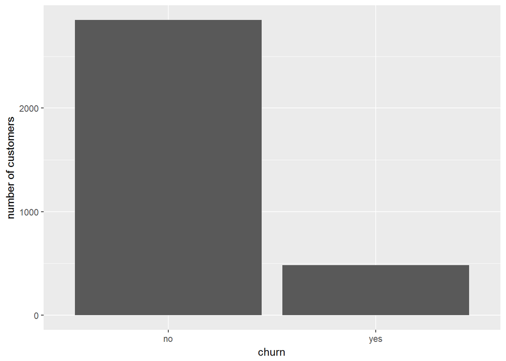

```r
library(ggplot2)
qplot(train$churn, xlab = "churn", ylab="number of customers")
```

```r
prop.table(table(train$churn))*100
```

```
##
##       no      yes
## 85.50855 14.49145
```

As the plot shows the customers who observed as churned are a small part of the data, only 14.4% are churned. This further may bring to a lower accuracy of the constructed models.

```r
str(train)
```

```
## 'data.frame':    3333 obs. of  21 variables:
##  $ X                            : int  1 2 3 4 5 6 7 8 9 10 ...
##  $ state                        : Factor w/ 51 levels "AK","AL","AR",..: 17 36 32 36 37 2 20 25 19 50 ...
##  $ account_length               : int  128 107 137 84 75 118 121 147 117 141 ...
##  $ area_code                    : Factor w/ 3 levels "area_code_408",..: 2 2 2 1 2 3 3 2 1 2 ...
##  $ international_plan           : Factor w/ 2 levels "no","yes": 1 1 1 2 2 2 1 2 1 2 ...
##  $ voice_mail_plan              : Factor w/ 2 levels "no","yes": 2 2 1 1 1 1 2 1 1 2 ...
##  $ number_vmail_messages        : int  25 26 0 0 0 0 24 0 0 37 ...
##  $ total_day_minutes            : num  265 162 243 299 167 ...
##  $ total_day_calls              : int  110 123 114 71 113 98 88 79 97 84 ...
##  $ total_day_charge             : num  45.1 27.5 41.4 50.9 28.3 ...
##  $ total_eve_minutes            : num  197.4 195.5 121.2 61.9 148.3 ...
##  $ total_eve_calls              : int  99 103 110 88 122 101 108 94 80 111 ...
##  $ total_eve_charge             : num  16.78 16.62 10.3 5.26 12.61 ...
##  $ total_night_minutes          : num  245 254 163 197 187 ...
##  $ total_night_calls            : int  91 103 104 89 121 118 118 96 90 97 ...
##  $ total_night_charge           : num  11.01 11.45 7.32 8.86 8.41 ...
##  $ total_intl_minutes           : num  10 13.7 12.2 6.6 10.1 6.3 7.5 7.1 8.7 11.2 ...
##  $ total_intl_calls             : int  3 3 5 7 3 6 7 6 4 5 ...
##  $ total_intl_charge            : num  2.7 3.7 3.29 1.78 2.73 1.7 2.03 1.92 2.35 3.02 ...
##  $ number_customer_service_calls: int  1 1 0 2 3 0 3 0 1 0 ...
##  $ churn                        : Factor w/ 2 levels "no","yes": 1 1 1 1 1 1 1 1 1 1 ...
```

```r
summary(train)
```

```
##        X            state      account_length          area_code
##  Min.   :   1   WV     : 106   Min.   :  1.0   area_code_408: 838
##  1st Qu.: 834   MN     :  84   1st Qu.: 74.0   area_code_415:1655
##  Median :1667   NY     :  83   Median :101.0   area_code_510: 840
##  Mean   :1667   AL     :  80   Mean   :101.1
##  3rd Qu.:2500   OH     :  78   3rd Qu.:127.0
##  Max.   :3333   OR     :  78   Max.   :243.0
##                 (Other):2824
##  international_plan voice_mail_plan number_vmail_messages
##  no :3010           no :2411        Min.   : 0.000
##  yes: 323           yes: 922        1st Qu.: 0.000
##                                     Median : 0.000
##                                     Mean   : 8.099
##                                     3rd Qu.:20.000
##                                     Max.   :51.000
##
##  total_day_minutes total_day_calls total_day_charge total_eve_minutes
##  Min.   :  0.0     Min.   :  0.0   Min.   : 0.00    Min.   :  0.0
##  1st Qu.:143.7     1st Qu.: 87.0   1st Qu.:24.43    1st Qu.:166.6
##  Median :179.4     Median :101.0   Median :30.50    Median :201.4
##  Mean   :179.8     Mean   :100.4   Mean   :30.56    Mean   :201.0
##  3rd Qu.:216.4     3rd Qu.:114.0   3rd Qu.:36.79    3rd Qu.:235.3
##  Max.   :350.8     Max.   :165.0   Max.   :59.64    Max.   :363.7
##
##  total_eve_calls total_eve_charge total_night_minutes total_night_calls
##  Min.   :  0.0   Min.   : 0.00    Min.   : 23.2       Min.   : 33.0
##  1st Qu.: 87.0   1st Qu.:14.16    1st Qu.:167.0       1st Qu.: 87.0
##  Median :100.0   Median :17.12    Median :201.2       Median :100.0
##  Mean   :100.1   Mean   :17.08    Mean   :200.9       Mean   :100.1
##  3rd Qu.:114.0   3rd Qu.:20.00    3rd Qu.:235.3       3rd Qu.:113.0
##  Max.   :170.0   Max.   :30.91    Max.   :395.0       Max.   :175.0
##
##  total_night_charge total_intl_minutes total_intl_calls total_intl_charge
##  Min.   : 1.040     Min.   : 0.00      Min.   : 0.000   Min.   :0.000
##  1st Qu.: 7.520     1st Qu.: 8.50      1st Qu.: 3.000   1st Qu.:2.300
##  Median : 9.050     Median :10.30      Median : 4.000   Median :2.780
##  Mean   : 9.039     Mean   :10.24      Mean   : 4.479   Mean   :2.765
##  3rd Qu.:10.590     3rd Qu.:12.10      3rd Qu.: 6.000   3rd Qu.:3.270
##  Max.   :17.770     Max.   :20.00      Max.   :20.000   Max.   :5.400
##
##  number_customer_service_calls churn
##  Min.   :0.000                 no :2850
##  1st Qu.:1.000                 yes: 483
##  Median :1.000
##  Mean   :1.563
##  3rd Qu.:2.000
##  Max.   :9.000
##
```

```r
length(table(train$state))
```

```
## [1] 51
```

# T-test and Chi-Squared test

T-test is to check which numeric variable raelly matters, and Pearson’s Chi-squared test is to understand whether there is relation between categorical variables and churn.

```r
t.test(train$total_day_charge~train$churn)
```

```
##
##  Welch Two Sample t-test
##
## data:  train$total_day_charge by train$churn
## t = -9.6845, df = 571.51, p-value < 2.2e-16
## alternative hypothesis: true difference in means is not equal to 0
## 95 percent confidence interval:
##  -6.489770 -4.301231
## sample estimates:
##  mean in group no mean in group yes
##          29.78042          35.17592
```

```r
t.test(train$total_eve_charge~train$churn)
```

```
##
##  Welch Two Sample t-test
##
## data:  train$total_eve_charge by train$churn
## t = -5.272, df = 646.01, p-value = 1.843e-07
## alternative hypothesis: true difference in means is not equal to 0
## 95 percent confidence interval:
##  -1.5592056 -0.7129148
## sample estimates:
##  mean in group no mean in group yes
##          16.91891          18.05497
```

```r
t.test(train$total_night_charge~train$churn)
```

```
##
##  Welch Two Sample t-test
##
## data:  train$total_night_charge by train$churn
## t = -2.171, df = 688.57, p-value = 0.03027
## alternative hypothesis: true difference in means is not equal to 0
## 95 percent confidence interval:
##  -0.43696811 -0.02194042
## sample estimates:
##  mean in group no mean in group yes
##          9.006074          9.235528
```

```r
t.test(train$number_customer_service_calls~train$churn)
```

```
##
##  Welch Two Sample t-test
##
## data:  train$number_customer_service_calls by train$churn
## t = -8.9551, df = 548.17, p-value < 2.2e-16
## alternative hypothesis: true difference in means is not equal to 0
## 95 percent confidence interval:
##  -0.9510789 -0.6088993
## sample estimates:
##  mean in group no mean in group yes
##          1.449825          2.229814
```

```r
t.test(train$total_intl_charge~train$churn)
```

```
##
##  Welch Two Sample t-test
##
## data:  train$total_intl_charge by train$churn
## t = -3.9399, df = 654.88, p-value = 9.026e-05
## alternative hypothesis: true difference in means is not equal to 0
## 95 percent confidence interval:
##  -0.21897510 -0.07330691
## sample estimates:
##  mean in group no mean in group yes
##          2.743404          2.889545
```

```r
t.test(train$number_vmail_messages~train$churn)
```

```
##
##  Welch Two Sample t-test
##
## data:  train$number_vmail_messages by train$churn
## t = 5.8213, df = 726.36, p-value = 8.765e-09
## alternative hypothesis: true difference in means is not equal to 0
## 95 percent confidence interval:
##  2.312072 4.665167
## sample estimates:
##  mean in group no mean in group yes
##          8.604561          5.115942
```

```r
t.test(train$total_intl_calls~train$churn)
```

```
##
##  Welch Two Sample t-test
##
## data:  train$total_intl_calls by train$churn
## t = 2.9604, df = 640.64, p-value = 0.003186
## alternative hypothesis: true difference in means is not equal to 0
## 95 percent confidence interval:
##  0.1243807 0.6144620
## sample estimates:
##  mean in group no mean in group yes
##          4.532982          4.163561
```

As results show all the tested variables are significant because in all cases p-values are less than 0.05.

```r
chisq.test(train$churn,train$area_code,simulate.p.value=T)
```

```
##
##  Pearson's Chi-squared test with simulated p-value (based on 2000
##  replicates)
##
## data:  train$churn and train$area_code
## X-squared = 0.17754, df = NA, p-value = 0.9125
```

```r
chisq.test(train$churn,train$international_plan,simulate.p.value = T)
```

```
##
##  Pearson's Chi-squared test with simulated p-value (based on 2000
##  replicates)
##
## data:  train$churn and train$international_plan
## X-squared = 225.05, df = NA, p-value = 0.0004998
```

```r
chisq.test(train$churn,train$state,simulate.p.value = T)
```

```
##
##  Pearson's Chi-squared test with simulated p-value (based on 2000
##  replicates)
##
## data:  train$churn and train$state
## X-squared = 83.044, df = NA, p-value = 0.003498
```

Chi-squared test for churn and area_code shows that p-value is more than 0.05, which means that there is no significant relationship between these two variables.

```r
library(caret)
set.seed(1982)
ctrl<-trainControl(method="cv", number=10)

paste(names(train),collapse = "+")
```

```
## [1] "X+state+account_length+area_code+international_plan+voice_mail_plan+number_vmail_messages+total_day_minutes+total_day_calls+total_day_charge+total_eve_minutes+total_eve_calls+total_eve_charge+total_night_minutes+total_night_calls+total_night_charge+total_intl_minutes+total_intl_calls+total_i…
```

```r
frm1<-(churn~state+account_length+international_plan+voice_mail_plan+number_vmail_messages+total_day_minutes+total_day_calls+total_day_charge+total_eve_minutes+total_eve_calls+total_eve_charge+total_night_minutes+total_night_calls+total_night_charge+total_intl_minutes+total_intl_calls+total_intl_charge+number_customer_service_calls)
```

```r
set.seed(400)
Fitknn <- train(frm1, data = train, method = "knn",
                trControl = ctrl,
                preProcess = c("center","scale"),
                tuneLength=10)
```

```r
Fitknn
```

```
## k-Nearest Neighbors
##
## 3333 samples
##   18 predictor
##    2 classes: 'no', 'yes'
##
## Pre-processing: centered (67), scaled (67)
## Resampling: Cross-Validated (10 fold)
## Summary of sample sizes: 3000, 3000, 2999, 3000, 2999, 3000, ...
## Resampling results across tuning parameters:
##
##   k   Accuracy   Kappa
##    5  0.8589892  0.091226980
##    7  0.8568862  0.056403989
##    9  0.8562865  0.027964046
##   11  0.8568862  0.029010048
##   13  0.8559871  0.013264431
##   15  0.8562883  0.014055854
##   17  0.8556877  0.007027927
##   19  0.8553874  0.003513963
##   21  0.8550871  0.000000000
##   23  0.8550871  0.000000000
##
## Accuracy was used to select the optimal model using  the largest value.
## The final value used for the model was k = 5.
```

As the accuracy tabble shows the model chooses k=5 as it has the best classification performance.

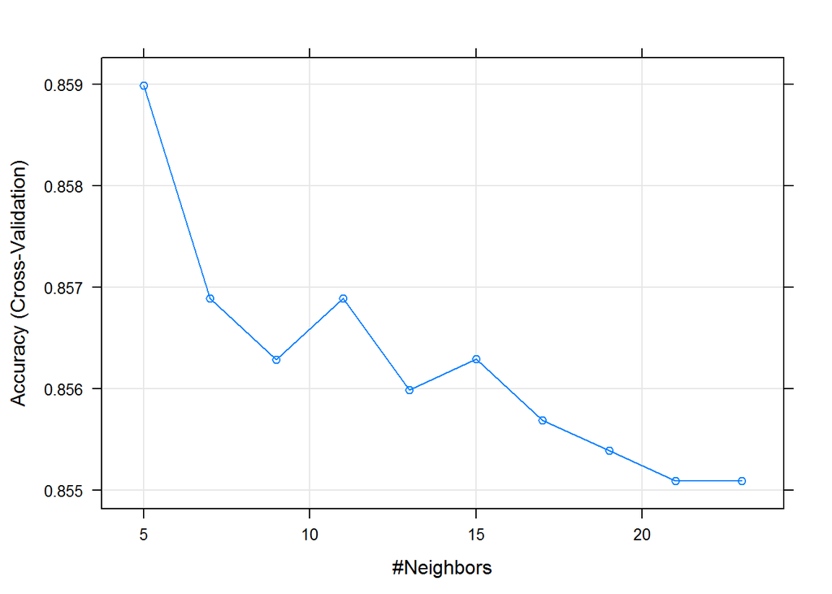

```r
plot(Fitknn)
```

The plot clearly shows that in case of k=5 the accuracy of model is the highest.

# Testing, Confusion Matrix

```r
library(caret)
test<-read.csv("Churn test.csv")
Predict_knn <- predict(Fitknn, newdata = test )

confusionMatrix(Predict_knn, test$churn, positive = "yes")
```

```
## Confusion Matrix and Statistics
##
##           Reference
## Prediction   no  yes
##        no  1429  201
##        yes   14   23
##
##                Accuracy : 0.871
##                  95% CI : (0.854, 0.8868)
##     No Information Rate : 0.8656
##     P-Value [Acc > NIR] : 0.2726
##
##                   Kappa : 0.1436
##  Mcnemar's Test P-Value : <2e-16
##
##             Sensitivity : 0.1027
##             Specificity : 0.9903
##          Pos Pred Value : 0.6216
##          Neg Pred Value : 0.8767
##              Prevalence : 0.1344
##          Detection Rate : 0.0138
##    Detection Prevalence : 0.0222
##       Balanced Accuracy : 0.5465
##
##        'Positive' Class : yes
##
```

# Roc Curve and AUC for KNN model

```r
knn_pr<-predict(Fitknn, newdata=test, type="prob")
library(ROCR)
```

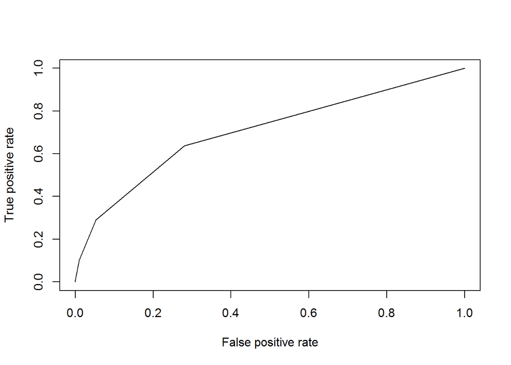

```r
P_Test <- prediction(knn_pr[,2], test$churn)
perf1<- performance(P_Test,"tpr","fpr")
plot(perf1)
```

```r
AUC_1<-performance(P_Test, "auc")@y.values
AUC_1
```

```
## [[1]]
## [1] 0.7042341
```

# Will this model do a good job for a telecom company that is trying to reduce churn rates?

I think that this model will not be the best option for a telecom company in making plan and strategy to reduce churn rate. First,sensitivity of the model is very low, which means that the model can not accurately predict those people who are going to churn. If a company based on this model start to spend money and resources to keep the customers who were predicted to churn, however it cannot keep customers as the model’s ability to find out most risky customers is very low. So, a company may spend resources ineffectively and the results may be not satisfing. Second, the model is only for classification and it doesn’t give chance to understand which explanatory variable how much will affect the decision of the customers.

# Applying Logistic regresson

I have decided to use logistic regression as I want to see which variable to what extent can affect the decision of the customers to churn or no. Also, this model will give chance to exclude those variables which are not significant, and then a telecome company may know which factors it should focus on to prevent customers to churn.

```r
logit1<-glm(frm1,data=train, family ="binomial")
summary(logit1)
```

```
##
## Call:
## glm(formula = frm1, family = "binomial", data = train)
##
## Deviance Residuals:
##     Min       1Q   Median       3Q      Max
## -1.9200  -0.4994  -0.3127  -0.1664   3.0363
##
## Coefficients:
##                                 Estimate Std. Error z value Pr(>|z|)
## (Intercept)                   -9.753e+00  9.756e-01  -9.996  < 2e-16 ***
## stateAL                        3.593e-01  7.627e-01   0.471 0.637573
## stateAR                        9.224e-01  7.521e-01   1.226 0.220040
## stateAZ                        1.089e-01  8.450e-01   0.129 0.897463
## stateCA                        1.821e+00  7.830e-01   2.326 0.020024 *
## stateCO                        6.675e-01  7.622e-01   0.876 0.381144
## stateCT                        1.034e+00  7.255e-01   1.426 0.153931
## stateDC                        6.979e-01  8.086e-01   0.863 0.388065
## stateDE                        7.521e-01  7.497e-01   1.003 0.315755
## stateFL                        5.983e-01  7.615e-01   0.786 0.432018
## stateGA                        6.685e-01  7.788e-01   0.858 0.390694
## stateHI                       -2.133e-01  8.960e-01  -0.238 0.811874
## stateIA                        2.115e-01  9.022e-01   0.234 0.814665
## stateID                        8.738e-01  7.480e-01   1.168 0.242719
## stateIL                       -2.206e-01  8.339e-01  -0.265 0.791350
## stateIN                        4.539e-01  7.526e-01   0.603 0.546413
## stateKS                        1.069e+00  7.297e-01   1.465 0.142794
## stateKY                        8.005e-01  7.658e-01   1.045 0.295850
## stateLA                        5.629e-01  8.360e-01   0.673 0.500722
## stateMA                        1.179e+00  7.433e-01   1.586 0.112673
## stateMD                        1.156e+00  7.169e-01   1.613 0.106744
## stateME                        1.335e+00  7.287e-01   1.832 0.066916 .
## stateMI                        1.403e+00  7.135e-01   1.966 0.049329 *
## stateMN                        1.163e+00  7.157e-01   1.625 0.104083
## stateMO                        6.023e-01  7.745e-01   0.778 0.436784
## stateMS                        1.362e+00  7.283e-01   1.871 0.061408 .
## stateMT                        1.878e+00  7.167e-01   2.620 0.008804 **
## stateNC                        5.993e-01  7.546e-01   0.794 0.427099
## stateND                        1.479e-01  7.966e-01   0.186 0.852729
## stateNE                        3.057e-01  8.061e-01   0.379 0.704570
```

[output cut: 33 more lines]

```
## total_night_charge             5.490e+00  2.008e+01   0.273 0.784494
## total_intl_minutes            -4.210e+00  5.492e+00  -0.767 0.443347
## total_intl_calls              -9.109e-02  2.575e-02  -3.537 0.000404 ***
## total_intl_charge              1.590e+01  2.034e+01   0.782 0.434347
## number_customer_service_calls  5.359e-01  4.095e-02  13.084  < 2e-16 ***
## ---
## Signif. codes:  0 '***' 0.001 '**' 0.01 '*' 0.05 '.' 0.1 ' ' 1
##
## (Dispersion parameter for binomial family taken to be 1)
##
##     Null deviance: 2758.3  on 3332  degrees of freedom
## Residual deviance: 2071.2  on 3265  degrees of freedom
## AIC: 2207.2
##
## Number of Fisher Scoring iterations: 6
```

As we can see, only 6 variables are significant in explayning whether the customer will churn or not.

#To check multicolinearity

```r
library(car)
vif(logit1)
```

```
##                                       GVIF Df GVIF^(1/(2*Df))
## state                         1.558515e+00 50        1.004447
## account_length                1.029630e+00  1        1.014707
## international_plan            1.143846e+00  1        1.069508
## voice_mail_plan               1.644451e+01  1        4.055183
## number_vmail_messages         1.638004e+01  1        4.047226
## total_day_minutes             9.992952e+06  1     3161.163118
## total_day_calls               1.039026e+00  1        1.019326
## total_day_charge              9.993002e+06  1     3161.171007
## total_eve_minutes             2.174300e+06  1     1474.550737
## total_eve_calls               1.031396e+00  1        1.015577
## total_eve_charge              2.174297e+06  1     1474.549757
## total_night_minutes           6.371647e+05  1      798.226000
## total_night_calls             1.035957e+00  1        1.017820
## total_night_charge            6.371590e+05  1      798.222378
## total_intl_minutes            6.985777e+04  1      264.306198
## total_intl_calls              1.032059e+00  1        1.015903
## total_intl_charge             6.985878e+04  1      264.308115
## number_customer_service_calls 1.138258e+00  1        1.066892
```

# Testing for logistic regression

```r
PredTest<-predict(logit1,newdata = test, type="response")

table(PredTest>0.5, test$churn)
```

```
##
##           no  yes
##   FALSE 1395  169
##   TRUE    48   55
```

```r
pr_label <-ifelse(PredTest>0.5, "yes", "no")

confusionMatrix(pr_label,test$churn,positive = "yes")
```

```
## Confusion Matrix and Statistics
##
##           Reference
## Prediction   no  yes
##        no  1395  169
##        yes   48   55
##
##                Accuracy : 0.8698
##                  95% CI : (0.8527, 0.8856)
##     No Information Rate : 0.8656
##     P-Value [Acc > NIR] : 0.3228
##
##                   Kappa : 0.275
##  Mcnemar's Test P-Value : 3.758e-16
##
##             Sensitivity : 0.24554
##             Specificity : 0.96674
##          Pos Pred Value : 0.53398
##          Neg Pred Value : 0.89194
##              Prevalence : 0.13437
##          Detection Rate : 0.03299
##    Detection Prevalence : 0.06179
##       Balanced Accuracy : 0.60614
##
##        'Positive' Class : yes
##
```

From confusion matrix, we can see that overall accuracy is 86.98% and sensitiviti=24.554% which is significantly higher than sensitivity of KNN model. Specificity=96.674, which is again quite high.

```r
ptst <- prediction(PredTest,test$churn)

perf2 <- performance(ptst,"tpr","fpr")
# AUC
AUC_2<-performance(ptst, "auc")@y.values
AUC_2
```

```
## [[1]]
## [1] 0.83342
```

AUC is again higher for logit model compared with KNN.

# ROC curve 2

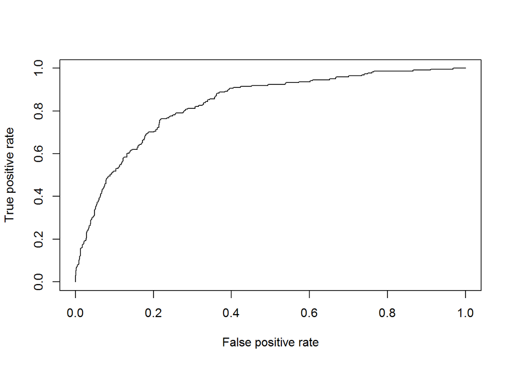

```r
# The ROC curve
plot(perf2)
```

Also, ROC curve shows that the logistic model is doing well for our data set compared with KNN.